# Regresión lineal y series de tiempo con Python y R

### Graficación

Inicialmente, realizaremos un gráfico de dispersión entre dos columnas del dataframe `df` como sigue:

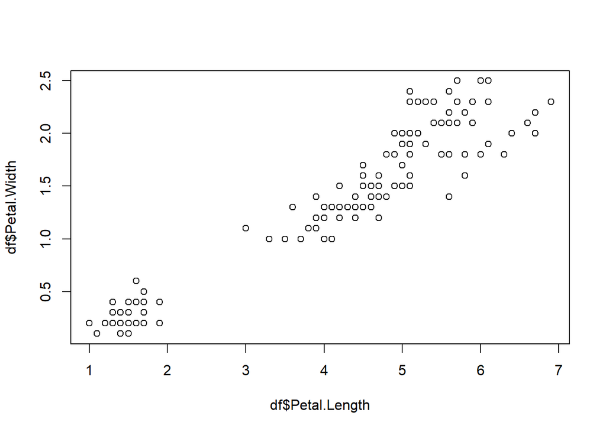

```r
plot(x=df$Petal.Length, y=df$Petal.Width)
```

Luego, tenemos que en ese dataframe la información de cada fila corresponde a una especie en específico

```r
df[ , c("Petal.Length", "Petal.Width", "Species")]
```

| Petal.Length | Petal.Width | Species |
| --- | --- | --- |
| 1.4 | 0.2 | setosa |
| 1.4 | 0.2 | setosa |
| 1.3 | 0.2 | setosa |
| 1.5 | 0.2 | setosa |
| 1.4 | 0.2 | setosa |
| 1.7 | 0.4 | setosa |
| 1.4 | 0.3 | setosa |
| 1.5 | 0.2 | setosa |
| 1.4 | 0.2 | setosa |
| 1.5 | 0.1 | setosa |

[output cut: 140 more lines]

donde solo hay tres especies

```r
# Con la funcion unique() obtenemos los valores diferentes en una columna
unique(df$Species)
```

```
## [1] setosa     versicolor virginica
## Levels: setosa versicolor virginica
```

Así, podemos colorear el diagrama de dispersión anterior de acuerdo a cada especie:

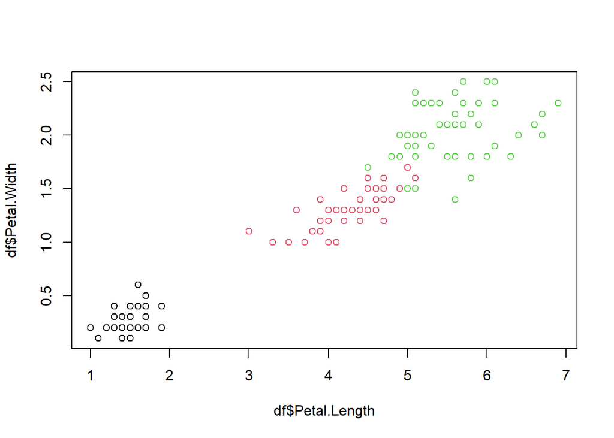

```r
# Agregamos el parametro col
plot(x=df$Petal.Length, y=df$Petal.Width, col=df$Species)
```

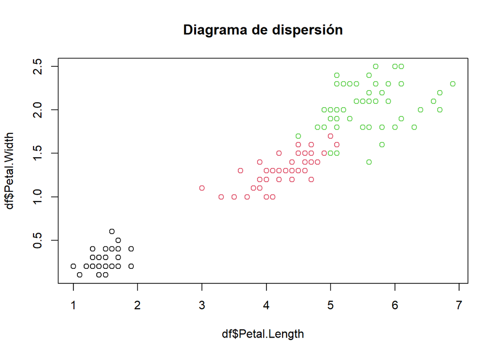

```r
plot(x=df$Petal.Length, y=df$Petal.Width, col=df$Species,
     # Agregamos un titulo al grafico
     main = "Diagrama de dispersión")
```

Podemos agregar una leyenda para saber a qué especie corresponde cada color

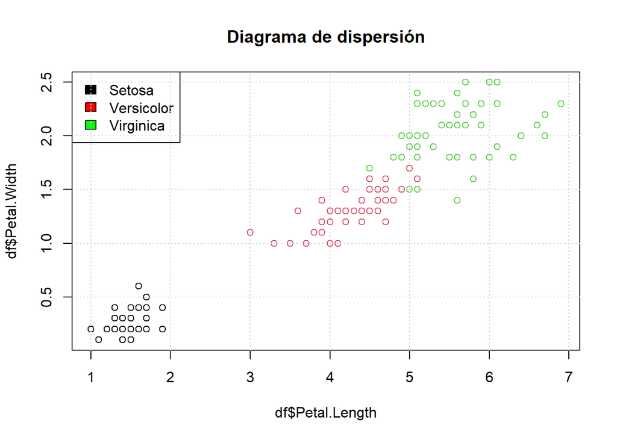

```r
plot(x=df$Petal.Length, y=df$Petal.Width, col=df$Species,
     main = "Diagrama de dispersión")
legend(x="topleft", legend = c("Setosa", "Versicolor", "Virginica"), fill=c("black", "red", "green"))
# Podemos agregar una cuadricula al grafico
grid()
```

donde

- `x` especifica la ubicación donde se colocarán las etiquetas.
- `legend` corresponde a las etiquetas que se mostrarán.
- `fill` el color de las etiquetas.

Ahora graficaremos un histograma, el cual nos permite observar la distribución de datos numéricos usando barras

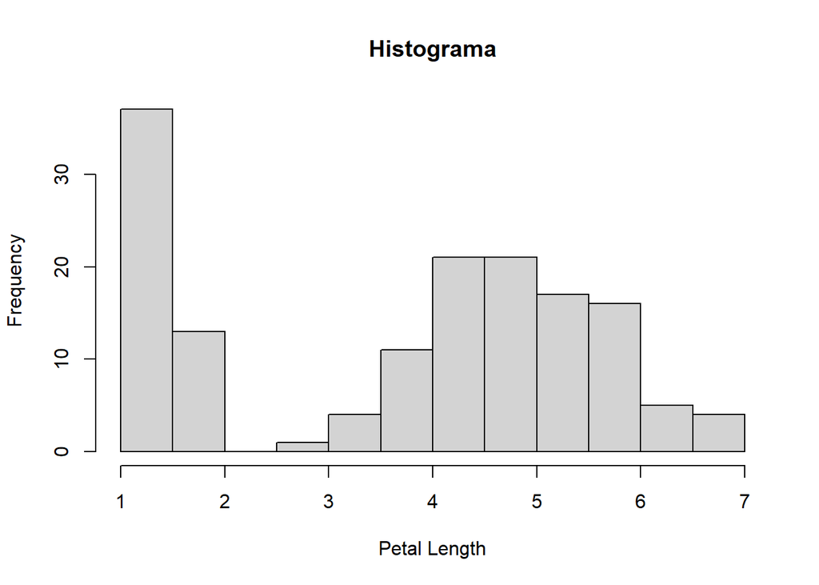

```r
# Graficamos un histograma
hist(x=df$Petal.Length, main = "Histograma",
     # Cambiaremos la etiqueta del eje x
     xlab = "Petal Length")
```

Podemos cambiar el color

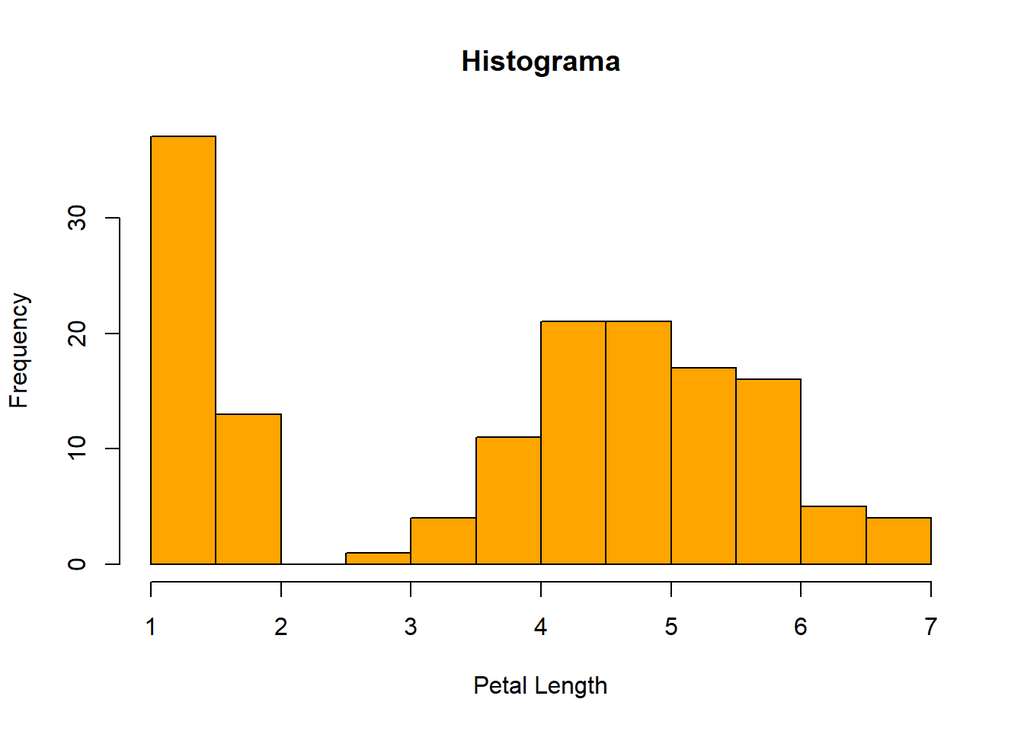

```r
hist(x=df$Petal.Length, main = "Histograma",
     xlab = "Petal Length",
     col = "orange")
```

Finalmente, lo que haremos será definir una función que siga la regla $f(x)=x^{2}$ y la graficaremos. Para crear una función escribiremos

```
nombre_de_la_funcion <- function(<<parametros>>){
  <<acciones que hace la funcion>>
  return(<<lo que regresa la funcion>>)
}
```

De tal manera

```r
# Definimos la funcion
f <- function(x){
  return(x ** 2)
}

# Probamos la funcion
f(4)
```

```
## [1] 16
```

Ahora la graficaremos:

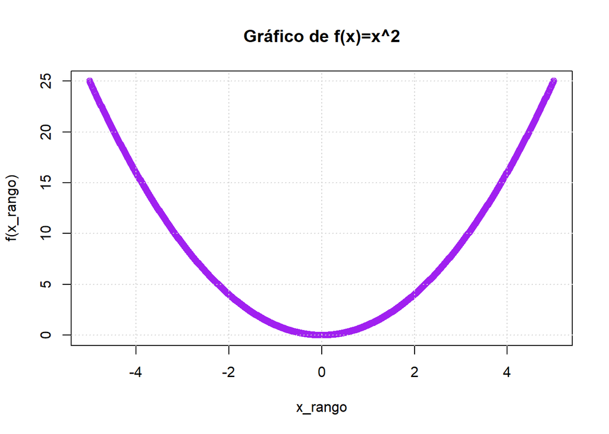

```r
# Creamos una secuencia de valor del -5 al 5 con un paso o avance de 0.01
x_rango <- seq(-5, 5, 0.01)

# Graficamos
plot(x_rango, f(x_rango), col="purple", main = "Gráfico de f(x)=x^2")
# Agregamos una cuadricula
grid()
```

## Manejo de datos en Python

```r
library(knitr)
include_graphics("pylogo.png")
```

[output not shown]

Para manejar datos como lo hicimos antes en `R` ocuparemos una librería de `Python` denominada `Pandas`, la cual nos permitirá trabajar con dataframes como lo hemos hecho antes. Para ello

### Librería Pandas

```python
# Cargamos la libreria y le asociamos un alias
import pandas as pd

# Importamos otra libreria la cual tiene conjuntos de datos integrados (como la libreria datasets de R)
import seaborn as sns
```

Luego, cargaremos el mismo conjunto de datos `iris`, pero ahora de la librería `seaborn`:

```python
# Cargamos los datos
df = sns.load_dataset("iris")

# Vemos los primeros 5 elementos con la funcion .head()
df.head(5)
```

```
##    sepal_length  sepal_width  petal_length  petal_width species
## 0           5.1          3.5           1.4          0.2  setosa
## 1           4.9          3.0           1.4          0.2  setosa
## 2           4.7          3.2           1.3          0.2  setosa
## 3           4.6          3.1           1.5          0.2  setosa
## 4           5.0          3.6           1.4          0.2  setosa
```

Luego, podemos obtener la información de una columna en particular

```python
# Dentro de los corchetes colocamos el nombre de la columna
df["sepal_length"]
```

```
## 0      5.1
## 1      4.9
## 2      4.7
## 3      4.6
## 4      5.0
##       ...
## 145    6.7
## 146    6.3
## 147    6.5
## 148    6.2
## 149    5.9
## Name: sepal_length, Length: 150, dtype: float64
```

si queremos acceder a información de más de una columna colocaremos los nombres de dichas columnas dentro otros corchetes:

```python
# Dentro de los corchetes colocamos el nombre de las columnas
df[["sepal_length", "sepal_width"]]
```

```
##      sepal_length  sepal_width
## 0             5.1          3.5
## 1             4.9          3.0
## 2             4.7          3.2
## 3             4.6          3.1
## 4             5.0          3.6
## ..            ...          ...
## 145           6.7          3.0
## 146           6.3          2.5
## 147           6.5          3.0
## 148           6.2          3.4
## 149           5.9          3.0
##
## [150 rows x 2 columns]
```

Podemos obtener la información de las primeras 9 filas:

```python
# En Python las numeraciones comienzan con el cero.
df[0:9]
```

```
##    sepal_length  sepal_width  petal_length  petal_width species
## 0           5.1          3.5           1.4          0.2  setosa
## 1           4.9          3.0           1.4          0.2  setosa
## 2           4.7          3.2           1.3          0.2  setosa
## 3           4.6          3.1           1.5          0.2  setosa
## 4           5.0          3.6           1.4          0.2  setosa
## 5           5.4          3.9           1.7          0.4  setosa
## 6           4.6          3.4           1.4          0.3  setosa
## 7           5.0          3.4           1.5          0.2  setosa
## 8           4.4          2.9           1.4          0.2  setosa
```

o las primeras 5 filas de una sola columna

```python
# Primero seleccionamos la columna y despues entre corchetes colocamos el rango 0:5 para seleccionar las primeras 5 filas
df["petal_length"][0:5]
```

```
## 0    1.4
## 1    1.4
## 2    1.3
## 3    1.5
## 4    1.4
## Name: petal_length, dtype: float64
```

**Nota:** En `R` escribíamos `df$Petal_Length` para acceder a los elementos de una columna, en `Python` escribimos `df["petal_length"]`.

Asimismo, podemos seleccionar elementos del dataframe dada una condición:

```python
# Colocamos nombre del dataframe, luego, entre corchetes
# accedemos a la columna sepal_width y ponemos la condicion
df[df["sepal_width"] > 4]
```

```
##     sepal_length  sepal_width  petal_length  petal_width species
## 15           5.7          4.4           1.5          0.4  setosa
## 32           5.2          4.1           1.5          0.1  setosa
## 33           5.5          4.2           1.4          0.2  setosa
```

o también

```python
# Elementos que tengan un numero mayor de 3.5 de sepal_width
# y (and, &) que tenga un numero mayor de 4.5 de sepal_length
df[(df["sepal_width"] > 3.5) & (df["sepal_length"] > 4.5) ]
```

```
##      sepal_length  sepal_width  petal_length  petal_width    species
## 4             5.0          3.6           1.4          0.2     setosa
## 5             5.4          3.9           1.7          0.4     setosa
## 10            5.4          3.7           1.5          0.2     setosa
## 14            5.8          4.0           1.2          0.2     setosa
## 15            5.7          4.4           1.5          0.4     setosa
## 16            5.4          3.9           1.3          0.4     setosa
## 18            5.7          3.8           1.7          0.3     setosa
## 19            5.1          3.8           1.5          0.3     setosa
## 21            5.1          3.7           1.5          0.4     setosa
## 22            4.6          3.6           1.0          0.2     setosa
## 32            5.2          4.1           1.5          0.1     setosa
## 33            5.5          4.2           1.4          0.2     setosa
## 37            4.9          3.6           1.4          0.1     setosa
## 44            5.1          3.8           1.9          0.4     setosa
## 46            5.1          3.8           1.6          0.2     setosa
## 48            5.3          3.7           1.5          0.2     setosa
## 109           7.2          3.6           6.1          2.5  virginica
## 117           7.7          3.8           6.7          2.2  virginica
## 131           7.9          3.8           6.4          2.0  virginica
```

El operador *or* es el mismo en `Python` que en `R`, esto es, el símbolo es `|`.

Por otro lado, podemos crear los dataframes en `Python`:

```python
# Creamos el dataframe con la funcion pd.DataFrame().
# Dentro de los parentesis colocaremos llaves
df_new = pd.DataFrame({
  # nombre   |los elementos de esta columna
  # de la    |los colocaremos entre
  # columna  |corchetes
  "Nombres": ["Luis", "Ana", "Fer"],
  "Edades" : [25, 30, 16]
})

# Veamos el dataframe
df_new
```

```
##   Nombres  Edades
## 0    Luis      25
## 1     Ana      30
## 2     Fer      16
```

De manera análoga en `R`, podremos agregar columnas nuevas:

```python
# Importacion necesaria para crear vectores (arrays)
import numpy as np

# Columna nueva     | rango de numeros del 0 al 2
df_new["Columna nueva"] = np.arange(0, 3, 1)

# Veamos de nuevo el dataframe
df_new
```

```
##   Nombres  Edades  Columna nueva
## 0    Luis      25              0
## 1     Ana      30              1
## 2     Fer      16              2
```

### Graficación

Con la librería `Pandas` podemos realizar de manera directa gráficos. Por ejemplo, para un diagrama de dispersión escribiremos `nombre_del_dataframe.plot.scatter(x=, y=)`, donde en `x` colocamos el nombre de la columna del dataframe `nombre_del_dataframe` que queremos que sea la variable independiente y en `y` la columna que queremos que sea la variable dependiente. Así:

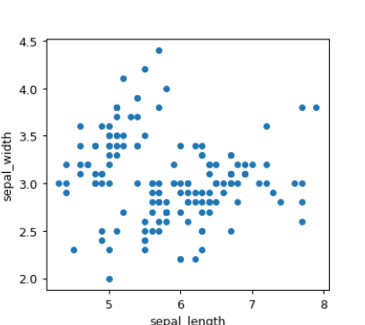

```python
df.plot.scatter(x = "sepal_length", y = "sepal_width")
```

Podemos cambiar el color y agregar un título

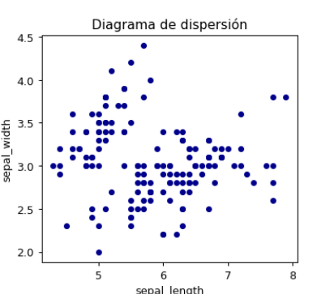

```python
df.plot.scatter(x = "sepal_length", y = "sepal_width", color="darkblue", title="Diagrama de dispersión")
```

Podemos graficar un histograma seleccionando primer la columna de interés, después colocamos `.plot.hist()` como sigue

[figure not shown]

```python
df["sepal_length"].plot.hist()
```

Finalmente, también podemos definir la función $f(x)=x^{2}$ en `Python` y después graficarla. Primero definimos la función. En este caso la estructura es:

```
def nombre_funcion(parametros):
  acciones_a_realizar
  return valor_a_regresar
```

Luego:

```python
# Definimos la funcion
def f(x):
  return x ** 2

# Probamos implementando un bucle for
for i in range(5):
  print(f(i))
```

```
## 0
## 1
## 4
## 9
## 16
```

Para graficar la función anterior nos vandremos de otra librería de graficación:

```python
# Importación necesaria
import matplotlib.pyplot as plt

# Creamos el rando de graficacion de -5 a 5 con un paso de 0.01
x_rango = np.arange(-5,5, 0.01)
```

Luego, para graficar escribimos

[figure not shown]

```python
# Creamos el grafico
plt.plot(x_rango, f(x_rango), color="red")
# Configuramos el titulo
plt.title
# Configuramos la etiqueta del eje x
plt.xlabel("Eje x")
# Configuramos la etiqueta del eje y
plt.ylabel("Eje y")
# Configuramos una cuadricula
plt.grid()
# Mostramos el grafico
plt.show()
```

## Ejercicios

### R

Considerando la librería `datasets`, carga el conjunto de datos `cars`. Luego

1. Realiza un gráfico de dispersión entre las dos columnas de dicho conjunto de datos. Deberás cambiar el color, agregarle un título y una cuadrícula al gráfico; además, cambia las etiquetas de los ejes.
2. Obtene información de dicho dataframe para aquellos registros donde `speed` sea mayor a 10 **y** donde `dist` sea menor a 20.
3. Obtén la información de las primeras 5 filas del dataframe, pero solo de la columna `dist`. Para obtener dicha información deberás de emplear dos formas distintas.
4. Al dataframe anterior, agrégale una nueva columna denominada `id` que contenga el rango de números del 1 al 50.
5. Crear un dataframe con la información de tu preferencia.
6. Define una función referente a la función matemática $f(x)=x^{3}$ y gráficala.

### Python

De la librería `seaborn`, carga el conjunto de datos `tips`.

1. Realiza un gráfico de dispersión entre las columnas `tip` y `total_bill`.
2. Obtén la información del dataframe para aquellos registros donde `tip` sea mayor a 5 **y** donde `smoker` sea igual (`==`) a `"No"`.
3. Define una función referente a la función matemática $f(x)=x^{3}$ y grafícala.